# Untitled

20180770 통계학과 배지혜

2021 1 30

```r
card <- read.csv("C:/Users/user/Desktop/AER_credit_card_data.csv", header = TRUE)
str(card)
```

```
## 'data.frame':    1319 obs. of  12 variables:
##  $ card       : chr  "yes" "yes" "yes" "yes" ...
##  $ reports    : int  0 0 0 0 0 0 0 0 0 0 ...
##  $ age        : num  37.7 33.2 33.7 30.5 32.2 ...
##  $ income     : num  4.52 2.42 4.5 2.54 9.79 ...
##  $ share      : num  0.03327 0.00522 0.00416 0.06521 0.06705 ...
##  $ expenditure: num  124.98 9.85 15 137.87 546.5 ...
##  $ owner      : chr  "yes" "no" "yes" "no" ...
##  $ selfemp    : chr  "no" "no" "no" "no" ...
##  $ dependents : int  3 3 4 0 2 0 2 0 0 0 ...
##  $ months     : int  54 34 58 25 64 54 7 77 97 65 ...
##  $ majorcards : int  1 1 1 1 1 1 1 1 1 1 ...
##  $ active     : int  12 13 5 7 5 1 5 3 6 18 ...
```

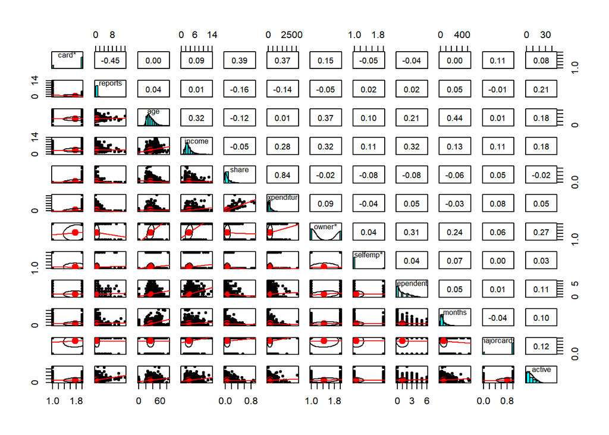

```r
library(ggplot2)
library(gridExtra)
library(dplyr)
library(psych)
pairs.panels(card, lm = TRUE)
```

모든 변수 간 산점도를 그렸을 때, 대체적으로 변수 간 낮은 상관계수의 값을 가진다는 것을 알 수 있음

## 신용카드신청 수락 여부 확인

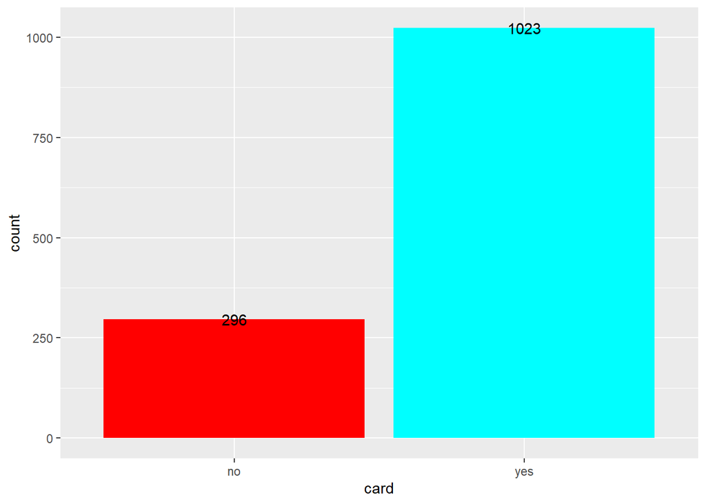

```r
ggplot(card, aes(card)) + geom_bar(fill = rainbow(2)) +
  geom_text(aes(label = ..count..), stat = "count", position = position_stack(1.0))
```

```r
card_01 <- card %>% filter(card == "yes")
card_01$age1[card_01$age<20] = "10대"
card_01$age1[card_01$age>=20 & card_01$age<30] = "20대"
card_01$age1[card_01$age>=30 & card_01$age<40] = "30대"
card_01$age1[card_01$age>=40 & card_01$age<50] = "40대"
card_01$age1[card_01$age>=50 & card_01$age<60] = "50대"
card_01$age1[card_01$age>=60 & card_01$age<70] = "60대"
card_01$age1[card_01$age>=70 & card_01$age<80] = "70대"
card_01$age1[card_01$age>=80 & card_01$age<90] = "80대"
card_01$major1[card_01$majorcards == 1] = "1개"
card_01$major1[card_01$majorcards == 0] = "0개"
head(card_01)
```

```
##   card reports      age income       share expenditure owner selfemp dependents
## 1  yes       0 37.66667 4.5200 0.033269910  124.983300   yes      no          3
## 2  yes       0 33.25000 2.4200 0.005216942    9.854167    no      no          3
## 3  yes       0 33.66667 4.5000 0.004155556   15.000000   yes      no          4
## 4  yes       0 30.50000 2.5400 0.065213780  137.869200    no      no          0
## 5  yes       0 32.16667 9.7867 0.067050590  546.503300   yes      no          2
## 6  yes       0 23.25000 2.5000 0.044438400   91.996670    no      no          0
##   months majorcards active age1 major1
## 1     54          1     12 30대    1개
## 2     34          1     13 30대    1개
## 3     58          1      5 30대    1개
## 4     25          1      7 30대    1개
## 5     64          1      5 30대    1개
## 6     54          1      1 20대    1개
```

## 신용카드 신청이 수락된 사람들이 가지고 있는 신용카드 수 비교

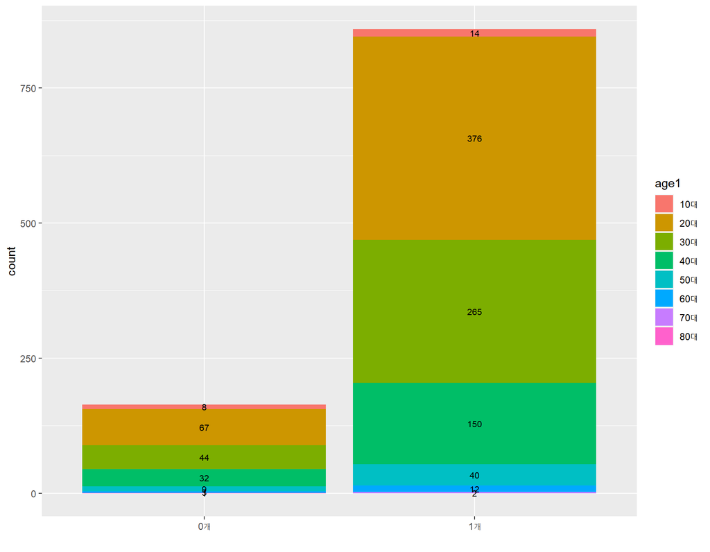

```r
ggplot(card_01, aes(major1, fill = age1)) + geom_bar() +
  geom_text(aes(label = ..count..), stat = "count", position = position_stack(0.5), size = 2.8) +
  xlab("")
```

-> 신용카드 신청이 수락된 사람 중 현재 가지고 있는 신용카드 수를 파악해보고자 하였는데, 주로 20~40대까지 신용카드를 이미 1개는 보유하고 있다는 것을 파악할 수 있음

## 카드를 소유한 사람은 신용계정을 몇 개나 가지고 있을까?

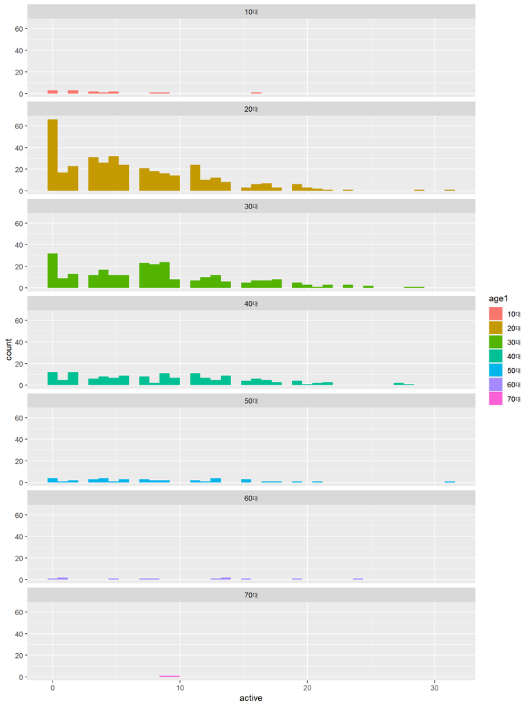

```r
card_02 <- card_01 %>% filter(majorcards == 1)
ggplot(card_02, aes(active, fill = age1 )) +
  geom_histogram(binwidth = .8) +
  facet_wrap(~age1, ncol=1)
```

-> 카드를 이미 1개 보유한 사람들 중 활성되어져 있는 신용 계정 수를 파악하고자 하였음. 20대~40대의 그림을 보면 활성화 된 계정의 수가 다른 집단 보다 많음을 파악할 수 있음.

## 그렇다면 신용 계정 수가 많을수록 소득과 월 평균 지출도 증가할까?

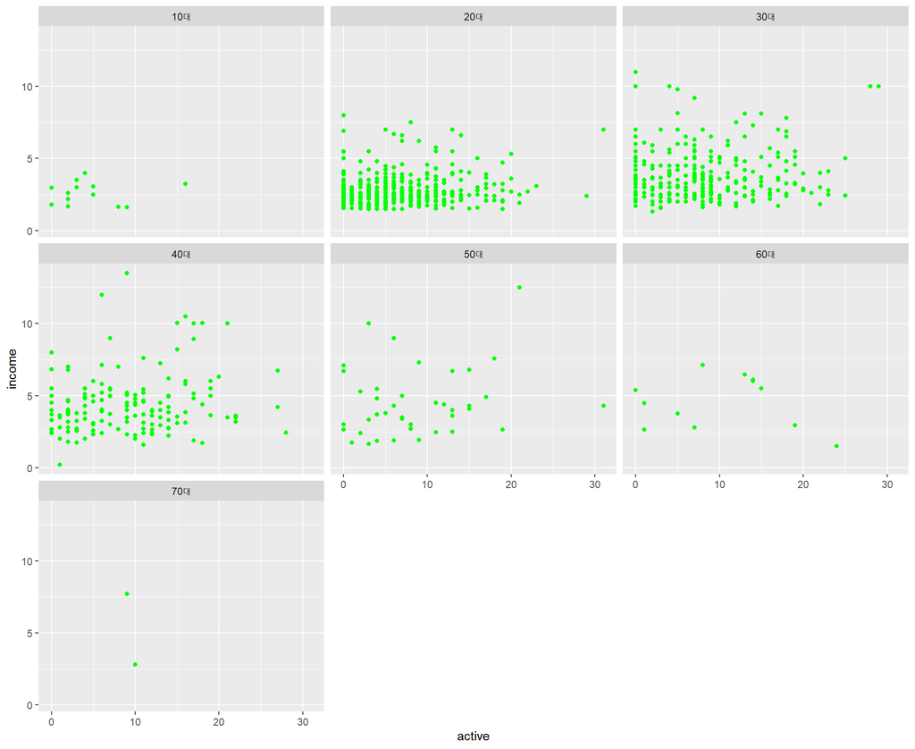

```r
ggplot(card_02, aes(x = active, y = income)) +
  geom_point(colour = "green") +
  facet_wrap(~age1)
```

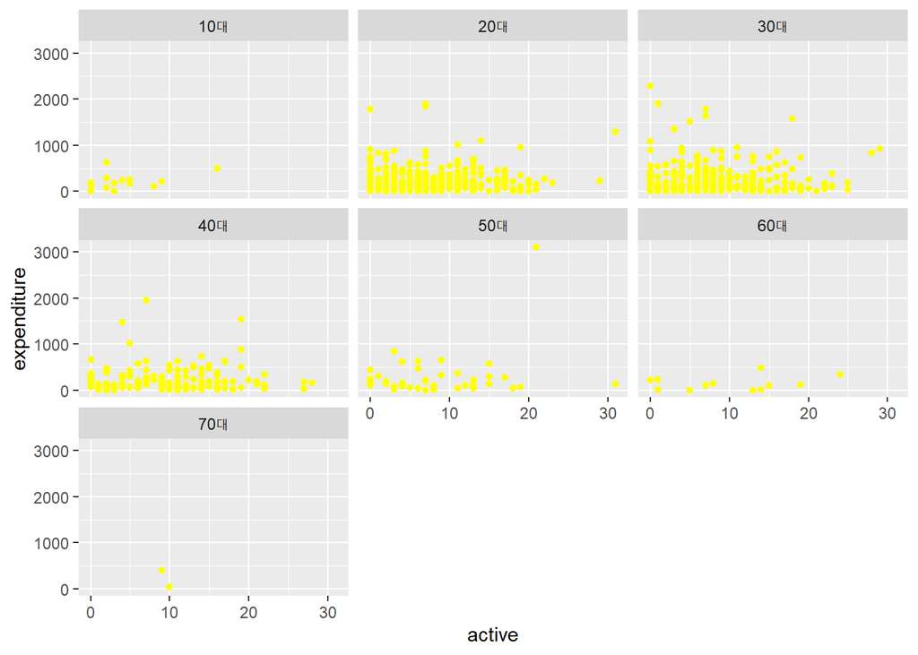

```r
ggplot(card_02, aes(x = active, y = expenditure)) +
  geom_point(colour = "yellow") +
  facet_wrap(~age1)
```

## 연령대별 부양가족 수 막대그래프

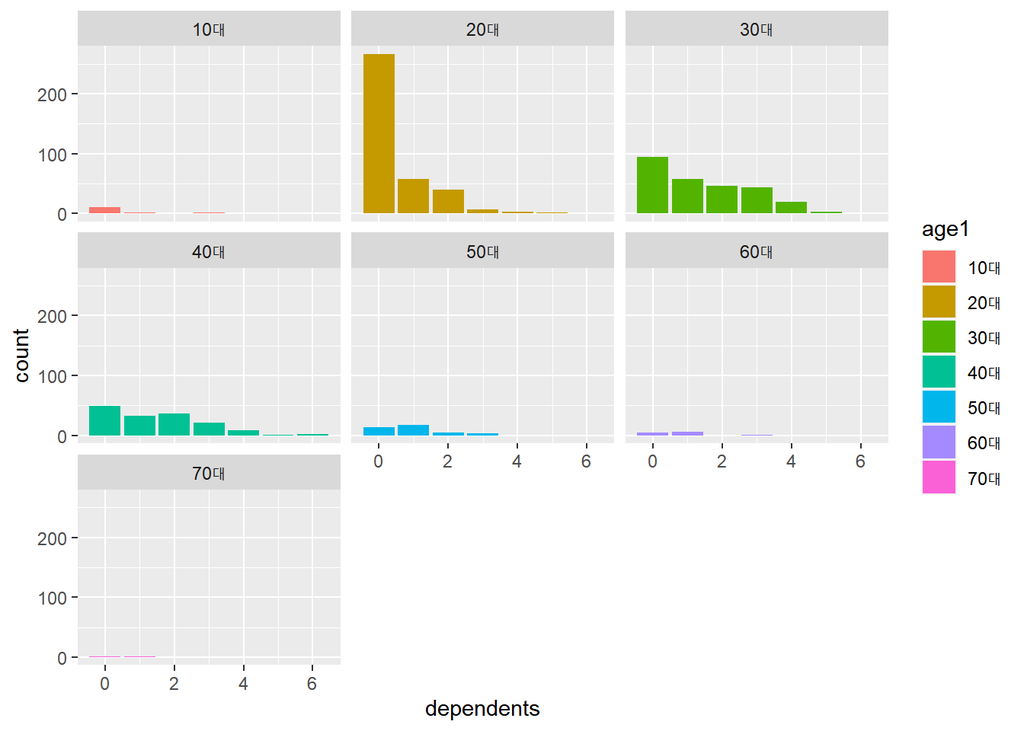

```r
ggplot(card_02, aes(dependents, fill = age1)) +
  geom_bar() +
  facet_wrap(~age1)
```

가족 부양 수는 30대와 40대가 다른 집단 보다 많음을 파악할 수 있다.

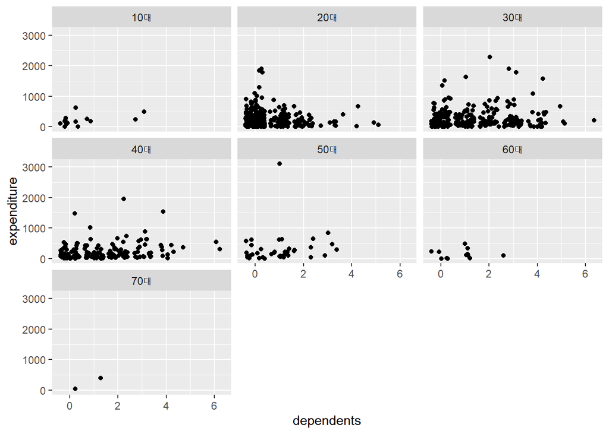

```r
ggplot(card_02, aes(x = dependents, y = expenditure)) +
  geom_jitter() +
  facet_wrap(~age1)
```

가족 부양 수가 많을 수록 지출 또한 증가하는지 살펴보기 위해 geom_jitter함수를 사용하여 그래프를 그려보았음.

## 지출과 가족부양수 회귀분석

```r
lm_01 <- lm(card$expenditure~card$dependents)
summary(lm_01)
```

```
##
## Call:
## lm(formula = card$expenditure ~ card$dependents)
##
## Residuals:
##     Min      1Q  Median      3Q     Max
## -242.58 -173.64  -82.87   67.45 2914.38
##
## Coefficients:
##                 Estimate Std. Error t value Pr(>|t|)
## (Intercept)      173.637      9.575  18.135   <2e-16 ***
## card$dependents   11.490      6.003   1.914   0.0559 .
## ---
## Signif. codes:  0 '***' 0.001 '**' 0.01 '*' 0.05 '.' 0.1 ' ' 1
##
## Residual standard error: 271.9 on 1317 degrees of freedom
## Multiple R-squared:  0.002774,   Adjusted R-squared:  0.002016
## F-statistic: 3.663 on 1 and 1317 DF,  p-value: 0.05585
```

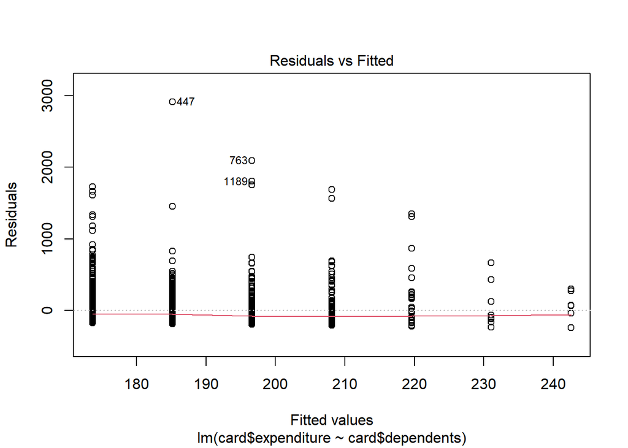

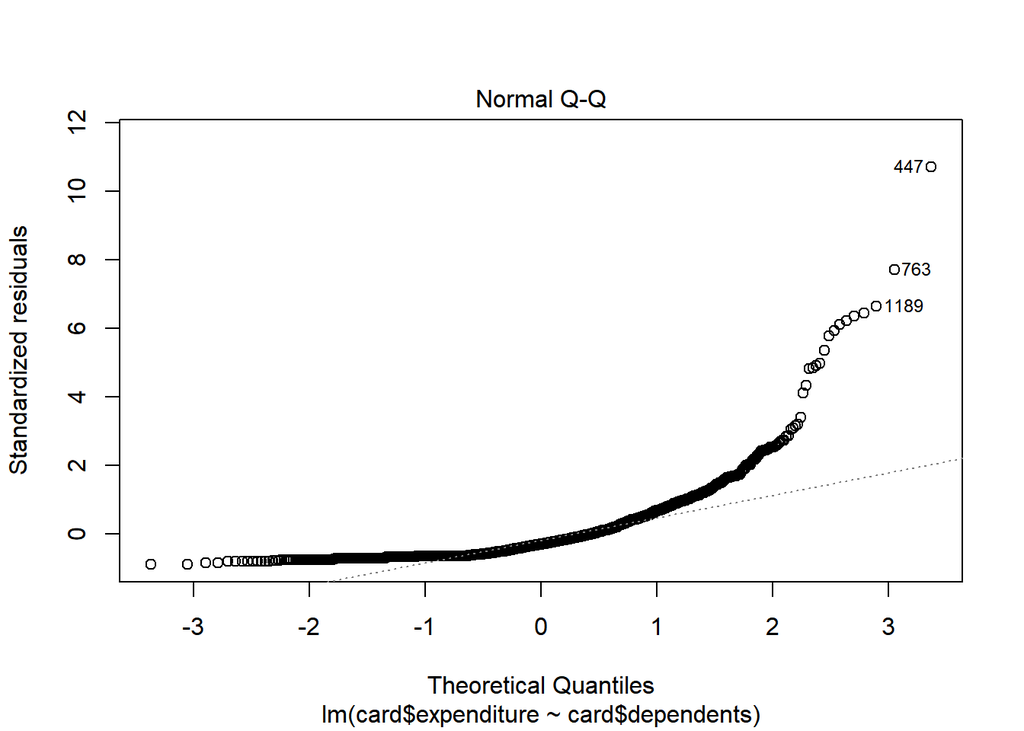

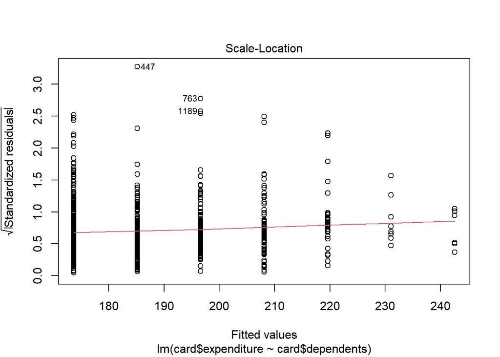

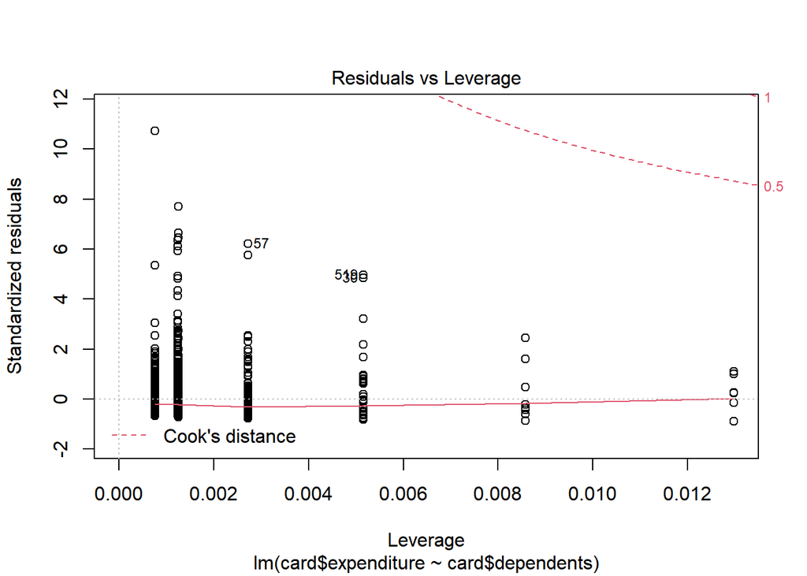

```r
plot(lm_01)
```

부양가족 수와 관련된 기울기의 p-값을 보면 0.05의 값을 초과하기 때문에 H0를 기각하지 못하여 이 회귀 모형은 유의한 모형이라 할 수 없다.

## 소득과 한달 지출간 회귀분석 돌려보기

```r
lm_02 <- lm(card$expenditure~ card$income)
summary(lm_02)
```

```
##
## Call:
## lm(formula = card$expenditure ~ card$income)
##
## Residuals:
##     Min      1Q  Median      3Q     Max
## -529.95 -139.19  -70.94   69.25 2501.80
##
## Coefficients:
##             Estimate Std. Error t value Pr(>|t|)
## (Intercept)    33.03      16.01   2.063   0.0393 *
## card$income    45.17       4.25  10.630   <2e-16 ***
## ---
## Signif. codes:  0 '***' 0.001 '**' 0.01 '*' 0.05 '.' 0.1 ' ' 1
##
## Residual standard error: 261.3 on 1317 degrees of freedom
## Multiple R-squared:  0.07902,    Adjusted R-squared:  0.07832
## F-statistic:   113 on 1 and 1317 DF,  p-value: < 2.2e-16
```

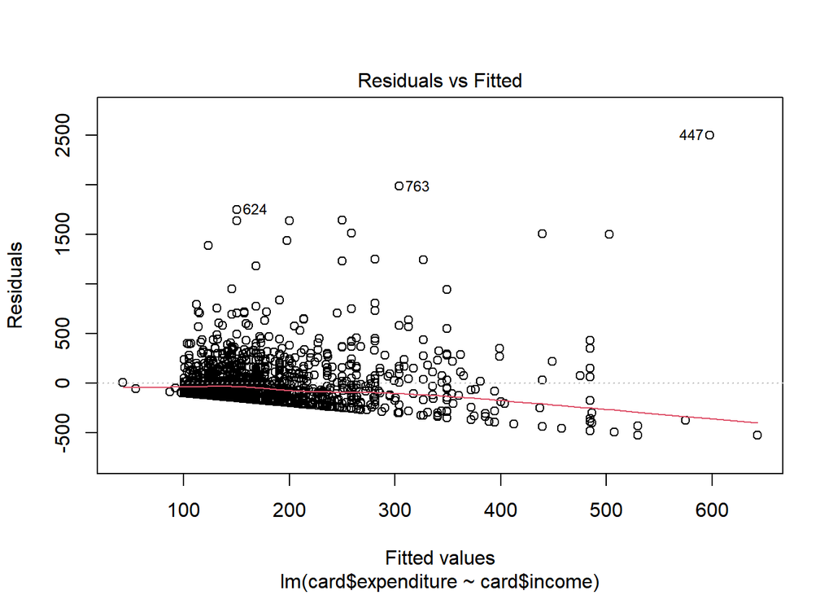

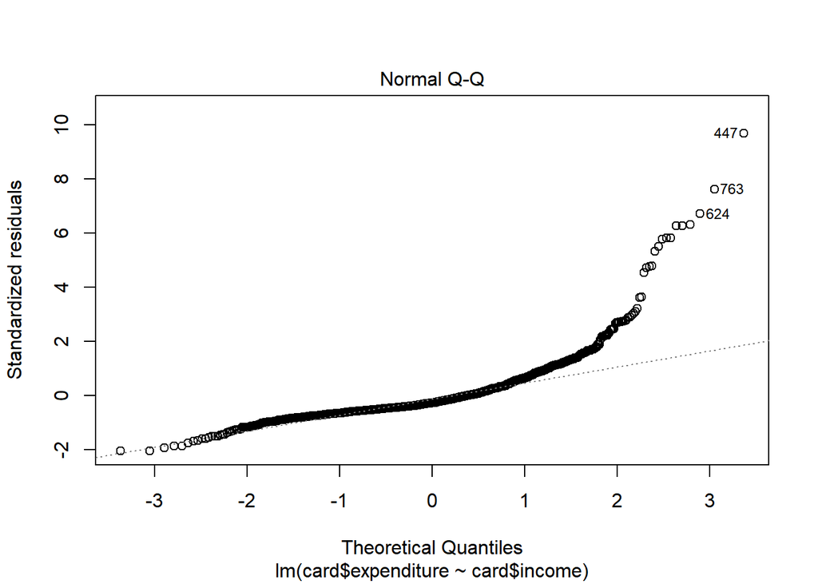

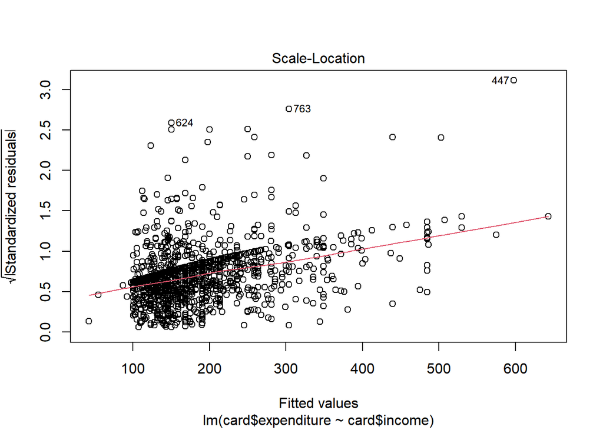

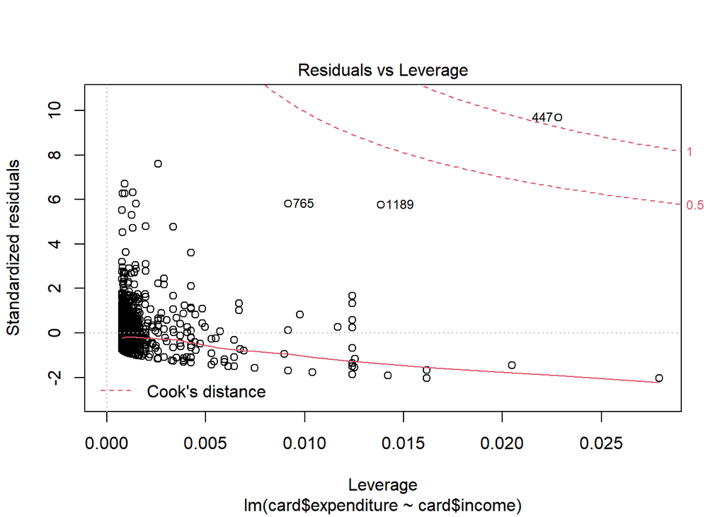

```r
plot(lm_02)
```

소득과 월평균 신용카드 지출 간 회귀 분석을 돌린 결과, 기울기와 절편에 대한 P-값이 모두 0.05보다 작으므로 귀무가설을 기각하여 유의한 모형이라고 판단할 수 있다. 그러나 Q-Q PLOT을 보면 점들이 Y=X의 직선 위에 위치해 있지 않고, income이 커지면 커질수록 점들의 모양이 곡선의 모양을 보인다는 것을 알 수 있다. 따라서 정규성을 위배한다고 할 수 있다. 이는 변수변환을 통해 모형의 안정화를 시켜줄 필요가 있음을 의미한다.